# Geospatial Risk Modeling: Theft from Automobiles in Washington, DC

Jenna Epstein

10/23/2020

# Setup

To setup, I load libraries, include functions, and define plot and map themes.

# Introduction

With advances in technology and data science in the public sector, there is increased demand for tools to help increase efficiency across government agencies. This is particularly evident in law enforcement in the United States, where “predictive policing” machine learning algorithms dominate the conversation. These tools use data to forecast crime, influence sentencing decisions, and control resource allocation and deployment. However, given the country’s deep-rooted systemic racism, the question of equity comes to the forefront.

In the era of Black Lives Matter, calls for equitable policing are only getting louder, and there is widespread critique around using machine learning for government decision-making. There are concerns that these tools lead to over-policing and misallocated resources by disproportionately targeting certain areas based on racial or socioeconomic status, further exacerbating systemic problems and reinforcing bias. Furthermore, the outsourcing of machine learning software to private companies obscures what is going on behind the scenes, as the “black box” of proprietary algorithms inhibits transparency.

In light of these challenges, is it possible for predictive modeling to be used to increase operational efficiency without exacerbating bias? What role can open source risk modeling play in moving the needle towards ethical and equitable decision-making? This exploration seeks to answer these questions through the creation of a geospatial risk model that optimizes for accuracy and generalizability for theft from automobile incidents in Washington, DC.

It is important to acknowledge that despite good intentions, there will still be some degree of bias in the risk predictions generated here. This is in large part due to unobserved information, especially for the outcome variable. The selection bias associated with theft from auto crime is discussed below.

# Data Wrangling

## Outcome Variable: Thefts from Automobiles

Model development assumes that crime risk is a function of exposure to risk factors: as exposure to these factors increases, crime risk increases. In this case, the outcome variable - the dependent variable - is theft from automobiles (referred to as “theft from auto” for the remainder of this document). This data comes from the city’s open data portal (opendatadc.gov).

The Metropolitan Police Department of Washington, DC (MPD) defines theft from auto as the theft of valuables from the inside of an automobile. For more information, please visit https://mpdc.dc.gov/page/thefts-autos. A type of property crime, theft from auto is one of the most common types of theft in DC.

This type of crime likely suffers from selection bias for a number of reasons. First, the people who are less likely to report thefts are those who do not want to contact law enforcement. This is particularly relevant in America today, where instances of police brutality against the Black community are becoming increasingly more visible. Given the state of systemic racism, these individuals may be less likely to call upon police for assistance, for fear of being mistreated or raising unwarranted suspicions. Additionally, dependent on the magnitude of the crime, people may be less inclined to report petty theft compared to theft of valuable items. The inconsistency in reporting, as well as likely under-reporting, means that the dataset is not truly representative of all incidents.

The set of maps below illustrate all theft from auto incidents recorded in 2018, both shown by individual points (left) and by density (right). Both maps show that there is a concentration of this type of crime in the center and right-center of the city. There are also clearly pockets in other areas of the city, so it is not unique to a specific neighborhood. The role of neighborhoods in the spatial process will be explored when running regressions. Density of crime incidents will also be further explored later on using kernel density maps to compare traditional hotspot mapping to the model’s risk predictions for future crime.

```r
#outcome variable
theftsFromAuto <-
  st_read("https://opendata.arcgis.com/datasets/38ba41dd74354563bce28a359b59324e_0.geojson") %>%
    filter(OFFENSE == "THEFT F/AUTO") %>%
    mutate(X = as.numeric(LONGITUDE),Y = as.numeric(LATITUDE)) %>%
    filter(!is.na(X)) %>%
    filter(!is.na(Y)) %>%
    st_as_sf(coords = c("X", "Y"), crs = 4326, agr = "constant")%>%
    st_transform('ESRI:102685') %>%
    distinct()

#DC boundary
boundaryDC <-
  st_read("https://opendata.arcgis.com/datasets/7241f6d500b44288ad983f0942b39663_10.geojson") %>%
  st_transform('ESRI:102685')

#DC police boundary data - not used in this version of the model, but keeping for reference
policeSectors <-
  st_read("https://opendata.arcgis.com/datasets/6ac17c2ff8cc4e20b3768dd1b98adf7a_23.geojson") %>%
  st_transform('ESRI:102685') %>%
  dplyr::select(Area = SECTOR)

policeServiceAreas <-
  st_read("https://opendata.arcgis.com/datasets/db24f3b7de994501aea97ce05a50547e_10.geojson") %>%
  st_transform('ESRI:102685') %>%
  dplyr::select(Area = NAME)

bothPoliceUnits <- rbind(mutate(policeSectors, Legend = "Police Sectors"),
                         mutate(policeServiceAreas, Legend = "Police Service Areas"))
```

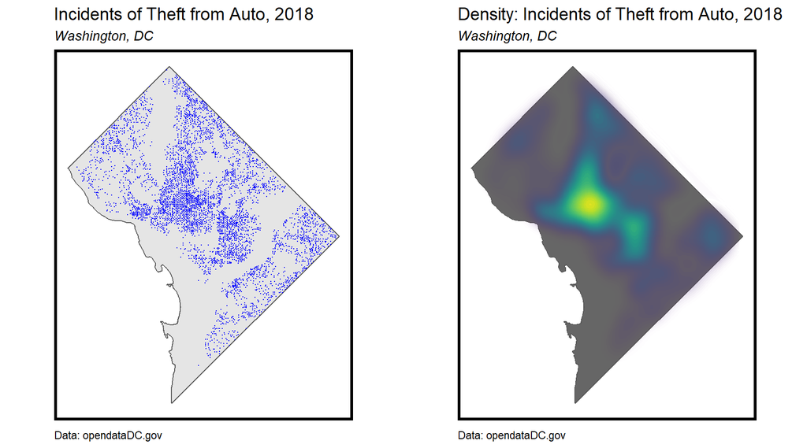

```r
# uses grid.arrange to organize independent plots
grid.arrange(ncol=2,
ggplot() +
  geom_sf(data = boundaryDC) +
  geom_sf(data = theftsFromAuto, colour="blue", size=0.1, show.legend = "point") +
  labs(title= "Incidents of Theft from Auto, 2018",
       subtitle="Washington, DC",
       caption="Data: opendataDC.gov") +
  mapTheme(),

ggplot() +
  geom_sf(data = boundaryDC, fill = "grey40") +
  stat_density2d(data = data.frame(st_coordinates(theftsFromAuto)),
                 aes(X, Y, fill = ..level.., alpha = ..level..),
                 size = 0.01, bins = 50, geom = 'polygon') +
  scale_fill_viridis() +
  scale_alpha(range = c(0.00, 0.35), guide = FALSE) +
  labs(title = "Density: Incidents of Theft from Auto, 2018",
       subtitle = "Washington, DC",
       caption="Data: opendataDC.gov") +
  mapTheme() + theme(legend.position = "none"))
```

Crime risk is not dependent on distinct municipal boundaries, so the city is divided up into a “fishnet” of grid cells, each 500 feet by 500 feet. After obtaining the count of theft by auto incidents for each of the grid cells, the data is aggregated to the fishnet by taking the sum of the counts per cell. This is visualized in the map below.

```r
fishnet <-
  st_make_grid(boundaryDC,
               cellsize = 500,
               square = TRUE) %>%
  .[boundaryDC] %>%
  st_sf() %>%
  mutate(uniqueID = rownames(.))
```

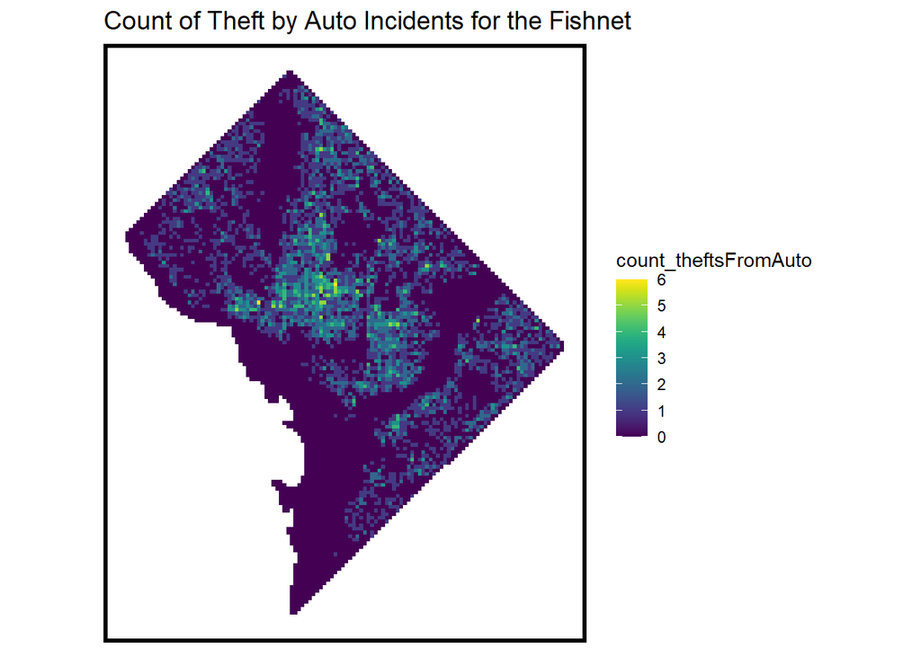

```r
## add a value of 1 to each crime, sum them with aggregate
theftsFromAuto_net <-
  dplyr::select(theftsFromAuto) %>%
  mutate(count_theftsFromAuto = 1) %>%
  aggregate(., fishnet, sum) %>%
  mutate(count_theftsFromAuto = replace_na(count_theftsFromAuto, 0),
         uniqueID = rownames(.),
         cvID = sample(round(nrow(fishnet) / 24),
                       size=nrow(fishnet), replace = TRUE))

ggplot() +
  geom_sf(data = theftsFromAuto_net, aes(fill = count_theftsFromAuto), color = NA) +
  scale_fill_viridis() +
  labs(title = "Count of Theft by Auto Incidents for the Fishnet") +
  mapTheme()
```

## Risk Factors

While the MPD warns about the risk of theft by auto in areas near bars and restaurants and large venues, there are other risk factors to explore when developing a predictive model. I read in data from opendatadc.gov to create a series of risk factor features. Seven out of eight of these variables come from the 2018 dataset of 311 reports; the liquor stores variable comes from a separate dataset housing point data for locations of liquor licenses in the city, filtered to only include stores. While other features were explored in the iterative model building process (including measuring distance to specific point locations of interest), ultimately a set of eight risk factors were best suited for the model:

- **Abandoned Cars:** reports of abandoned vehicles on both public and private property
- **Alley Cleaning:** reports of alleys in need of cleaning
- **Graffiti:** reports of graffiti in need of removal
- **Liquor Stores:** locations of stores with liquor licenses that sell liquor
- **Parking Enforcement:** reports of parking violations
- **Sanitation Enforcement:** reports of improper disposal of trash
- **Street Light Repair:** reports of malfunctioning street lights
- **Vacant Lots:** reports of vacant lots

A neighborhoods dataset - a polygon layer from opendatadc.gov - is also incorporated at this time.

```r
## risk factors
abandonedCars <-
  st_read("https://opendata.arcgis.com/datasets/2a46f1f1aad04940b83e75e744eb3b09_9.geojson") %>%
  filter(SERVICECODEDESCRIPTION %in% c("Abandoned Vehicle - On Public Property", "Abandoned Vehicle - On Private Property")) %>%
  dplyr::select(Y = LATITUDE, X = LONGITUDE) %>%
    na.omit() %>%
    st_as_sf(coords = c("X", "Y"), crs = 4326, agr = "constant") %>%
    st_transform(st_crs(fishnet)) %>%
    mutate(Legend = "Abandoned Cars")

alleyCleaning <-
  st_read("https://opendata.arcgis.com/datasets/2a46f1f1aad04940b83e75e744eb3b09_9.geojson") %>%
  filter(SERVICECODEDESCRIPTION == "Alley Cleaning") %>%
  dplyr::select(Y = LATITUDE, X = LONGITUDE) %>%
    na.omit() %>%
    st_as_sf(coords = c("X", "Y"), crs = 4326, agr = "constant") %>%
    st_transform(st_crs(fishnet)) %>%
    mutate(Legend = "Alley Cleaning")

graffiti <-
  st_read("https://opendata.arcgis.com/datasets/2a46f1f1aad04940b83e75e744eb3b09_9.geojson") %>%
  filter(SERVICECODEDESCRIPTION == "Graffiti Removal") %>%
  dplyr::select(Y = LATITUDE, X = LONGITUDE) %>%
    na.omit() %>%
    st_as_sf(coords = c("X", "Y"), crs = 4326, agr = "constant") %>%
    st_transform(st_crs(fishnet)) %>%
    mutate(Legend = "Graffiti")

parkingEnf <-
  st_read("https://opendata.arcgis.com/datasets/2a46f1f1aad04940b83e75e744eb3b09_9.geojson") %>%
  filter(SERVICECODEDESCRIPTION == "Parking Enforcement") %>%
  dplyr::select(Y = LATITUDE, X = LONGITUDE) %>%
    na.omit() %>%
    st_as_sf(coords = c("X", "Y"), crs = 4326, agr = "constant") %>%
    st_transform(st_crs(fishnet)) %>%
    mutate(Legend = "Parking Enforcement")

sanitationEnf <-
  st_read("https://opendata.arcgis.com/datasets/2a46f1f1aad04940b83e75e744eb3b09_9.geojson") %>%
  filter(SERVICECODEDESCRIPTION == "Sanitation Enforcement") %>%
  dplyr::select(Y = LATITUDE, X = LONGITUDE) %>%
    na.omit() %>%
    st_as_sf(coords = c("X", "Y"), crs = 4326, agr = "constant") %>%
    st_transform(st_crs(fishnet)) %>%
    mutate(Legend = "Sanitation Enforcement")

streetlightRepair <-
  st_read("https://opendata.arcgis.com/datasets/2a46f1f1aad04940b83e75e744eb3b09_9.geojson") %>%
  filter(SERVICECODEDESCRIPTION == "Streetlight Repair Investigation") %>%
  dplyr::select(Y = LATITUDE, X = LONGITUDE) %>%
    na.omit() %>%
    st_as_sf(coords = c("X", "Y"), crs = 4326, agr = "constant") %>%
    st_transform(st_crs(fishnet)) %>%
    mutate(Legend = "Street Light Repair")

vacantLots <-
  st_read("https://opendata.arcgis.com/datasets/2a46f1f1aad04940b83e75e744eb3b09_9.geojson") %>%
  filter(SERVICECODEDESCRIPTION == "Vacant Lot - Public Property Only") %>%
  dplyr::select(Y = LATITUDE, X = LONGITUDE) %>%
    na.omit() %>%
    st_as_sf(coords = c("X", "Y"), crs = 4326, agr = "constant") %>%
    st_transform(st_crs(fishnet)) %>%
    mutate(Legend = "Vacant Lots")

liquorStores <-
  st_read("https://opendata.arcgis.com/datasets/cabe9dcef0b344518c7fae1a3def7de1_5.geojson") %>%
  filter(TYPE == "Retail - Liquor Store") %>%
  dplyr::select(Y = LATITUDE, X = LONGITUDE) %>%
    na.omit() %>%
    st_as_sf(coords = c("X", "Y"), crs = 4326, agr = "constant") %>%
    st_transform(st_crs(fishnet)) %>%
    mutate(Legend = "Liquor Stores")

#Reading in DC Neighborhoods Spatial Data
neighborhoods <-
  st_read("https://opendata.arcgis.com/datasets/de63a68eb7674548ae0ac01867123f7e_13.geojson") %>%
  dplyr::select(OBJECTID, DC_HPN_NAME, geometry) %>%
  dplyr::rename(NAME = DC_HPN_NAME) %>%
  st_transform(st_crs(fishnet))
```

# Feature Engineering

## Count of Risk Factors by Fishnet Grid Cell

Now that the wrangling of the risk factors is complete, they are joined to the fishnet. The small multiple plot below illustrates how the features have different spatial processes. By visualizing these risk factors, it is clear that they have different spatial processes. For example, reports of graffiti are concentrated in the center of the city, whereas street lights in need of repair are distributed across many areas.

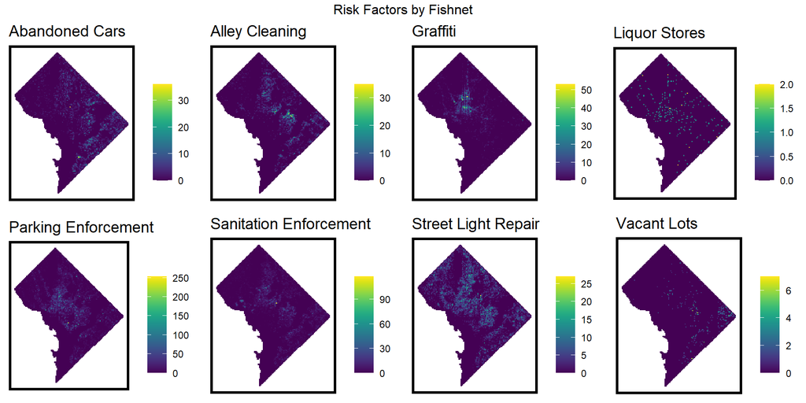

```r
## Aggregating Risk Factors (Features) to the Fishnet Grid using Nearest Neighbor
vars_net <-
rbind(abandonedCars, alleyCleaning, graffiti, parkingEnf, sanitationEnf, streetlightRepair, vacantLots, liquorStores) %>%
  st_join(., fishnet, join=st_within) %>%
  st_drop_geometry() %>%
  group_by(uniqueID, Legend) %>%
  summarize(count = n()) %>%
    full_join(fishnet, by="uniqueID") %>%
    spread(Legend, count, fill=0) %>%
    st_sf() %>%
    dplyr::select(-`<NA>`) %>%
    na.omit() %>%
    ungroup()

vars_net.long <-
  gather(vars_net, Variable, value, -geometry, -uniqueID)

#plotting
vars <- unique(vars_net.long$Variable)
mapList <- list()

for(i in vars){
  mapList[[i]] <-
    ggplot() +
      geom_sf(data = filter(vars_net.long, Variable == i), aes(fill=value), colour=NA) +
      scale_fill_viridis(name="") +
      labs(title=i) +
      mapTheme()}

do.call(grid.arrange,c(mapList, ncol =4, top = "Risk Factors by Fishnet"))
```

## Nearest Neighbor Features

Another feature engineering approach is explored as an alternative to using grid cell count: calculating nearest neighbor distance. This approach takes the centroid of each cell and measures its distance to its three nearest neighbors of each risk factor variable category.

This approach is chosen over the count by grid cells to better account for smoother exposure to risk factors across space. The small multiple plot below visualizes these nearest neighbor features.

```r
st_c <- st_coordinates
st_coid <- st_centroid

vars_net <-
  vars_net %>%
    mutate(
      Abandoned_Cars.nn =
        nn_function(st_c(st_coid(vars_net)), st_c(abandonedCars),3),
      Alley_Cleaning.nn =
        nn_function(st_c(st_coid(vars_net)), st_c(alleyCleaning),3),
      Graffiti.nn =
        nn_function(st_c(st_coid(vars_net)), st_c(graffiti),3),
      Liquor_Retail.nn =
        nn_function(st_c(st_coid(vars_net)), st_c(liquorStores),3),
      Parking_Enforcement.nn =
        nn_function(st_c(st_coid(vars_net)), st_c(parkingEnf),3),
      Sanitation_Enforcement.nn =
        nn_function(st_c(st_coid(vars_net)), st_c(sanitationEnf),3),
      Street_Light_Repair.nn =
        nn_function(st_c(st_coid(vars_net)), st_c(streetlightRepair),3),
      Vacant_Lots.nn =
        nn_function(st_c(st_coid(vars_net)), st_c(vacantLots),3))
```

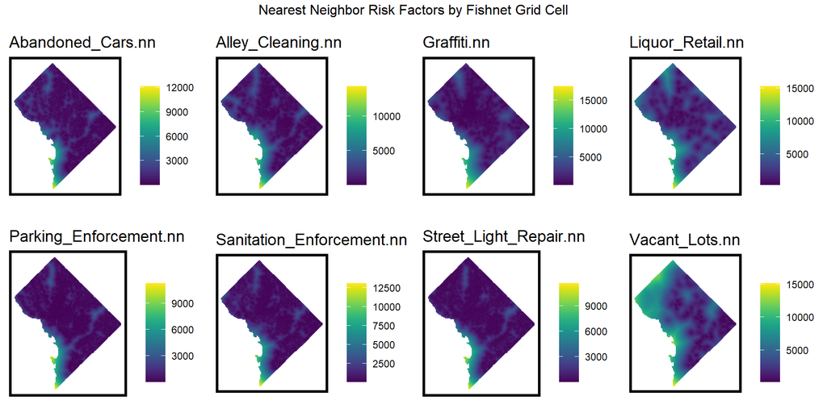

```r
vars_net.long.nn <-
  dplyr::select(vars_net, ends_with(".nn")) %>%
    gather(Variable, value, -geometry)

vars <- unique(vars_net.long.nn$Variable)
mapList <- list()

for(i in vars){
  mapList[[i]] <-
    ggplot() +
      geom_sf(data = filter(vars_net.long.nn, Variable == i), aes(fill=value), colour=NA) +
      scale_fill_viridis(name="") +
      labs(title=i) +
      mapTheme()}

do.call(grid.arrange,c(mapList, ncol = 4, top = "Nearest Neighbor Risk Factors by Fishnet Grid Cell"))
```

## Creating the Final Fishnet Grid

After selecting the nearest neighbor features approach for incorporating risk factors, a final fishnet is created that joins together the risk factors and the theft by auto incidents.

```r
final_net <-
  left_join(theftsFromAuto_net, st_drop_geometry(vars_net), by="uniqueID")

final_net <-
  st_centroid(final_net) %>%
    st_join(dplyr::select(neighborhoods, NAME)) %>%
    st_join(dplyr::select(policeSectors, Area)) %>%
      st_drop_geometry() %>%
      left_join(dplyr::select(final_net, geometry, uniqueID)) %>%
      st_sf() %>%
  na.omit()
```

# Exploring the Spatial Process of Theft from Auto Incidents

## Local Moran’s *I*

The Local Moran’s *I* statistic is calculated to explore local spatial autocorrelation of theft from auto incidents in Washington, DC. The statistic assumes that at at a given point, the count of incidents is randomly distributed. Essentially, it explores spatial clustering by measuring how similar locations are to their immediate neighbors. High Local Moran’s *I* values indicate that there is evidence of local clustering.

```r
## {spdep} to make polygon to neighborhoods
final_net.nb <- poly2nb(as_Spatial(final_net), queen=TRUE)
## and neighborhoods to list of weights
final_net.weights <- nb2listw(final_net.nb, style="W", zero.policy=TRUE)

final_net.localMorans <-
  cbind(
    as.data.frame(localmoran(final_net$count_theftsFromAuto, final_net.weights)),
    as.data.frame(final_net)) %>%
    st_sf() %>%
      dplyr::select(theftsFromAuto_Count = count_theftsFromAuto,
                    Local_Morans_I = Ii,
                    P_Value = `Pr(z > 0)`) %>%
      mutate(Significant_Hotspots = ifelse(P_Value <= 0.05, 1, 0)) %>%
      gather(Variable, Value, -geometry)
```

The results of the Local Moran’s *I* are plotted below, alongside the count of incidents (on the far left). These three outputs mapped include the Local Moran’s *I*, the p-value, and the significant hotspots (cells with higher local counts than expected).

In the Local Moran’s *I* map, evidence of spatial clustering exists especially in the center areas of the city, as evidenced by the higher values for cells (shown in green and yellow hues). The p-value and significant hotspots maps further support this notion of local clustering.

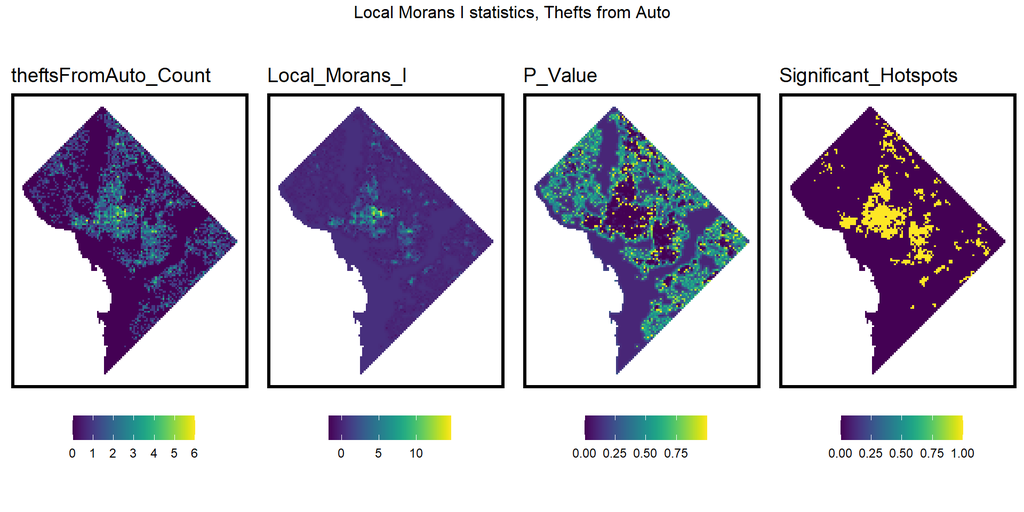

```r
vars2 <- unique(final_net.localMorans$Variable)
varList <- list()

for(i in vars2){
  varList[[i]] <-
    ggplot() +
      geom_sf(data = filter(final_net.localMorans, Variable == i),
              aes(fill = Value), colour=NA) +
      scale_fill_viridis(name="") +
      labs(title=i) +
      mapTheme() + theme(legend.position="bottom")}

do.call(grid.arrange,c(varList, ncol = 4, top = "Local Morans I statistics, Thefts from Auto"))
```

### Plotting Nearest Neighbor Distance to Hotspots

In order to develop a model that generalizes well, it must predict well in the hotspots and in the not-so-hotspots. To control for spatial process, Local Moran’s *I* is added as a feature in the final fishnet grid, using a dummy variable to indicate that a cell is part of a significant cluster. Then, the average nearest neighbor distance is measured from the centroid of each grid cell to its nearest significant cluster. The p-value chosen is 0.0000001 - the smaller the p-value, the more significant the clusters.

The map below shows the distance to highly significant hotspots for thefts from automobiles.

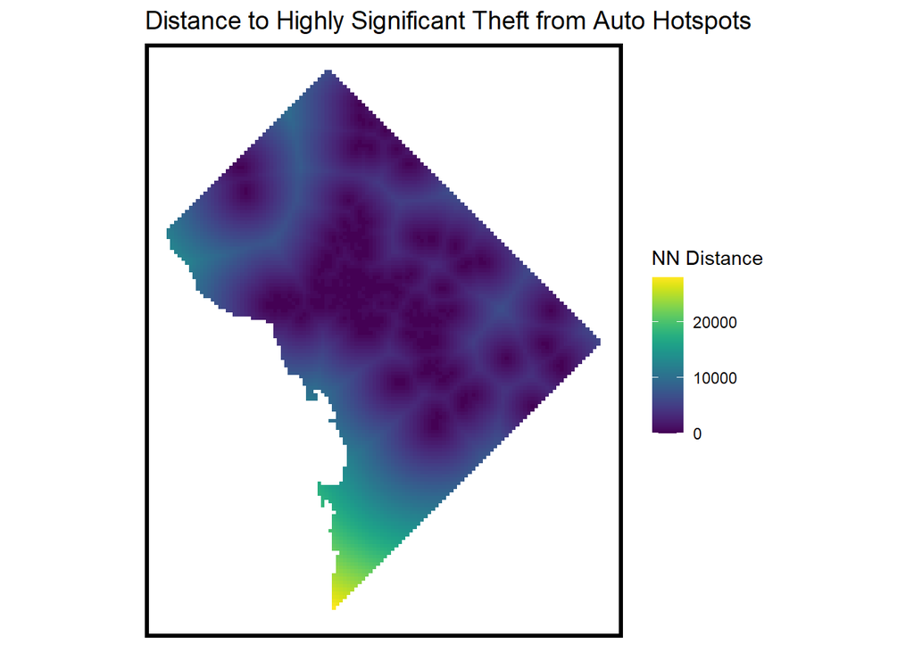

```r
# first, create a Local Moran's I feature in final_net
final_net <-
  final_net %>%
  mutate(theftsFromAuto.isSig =
           ifelse(localmoran(final_net$count_theftsFromAuto,
                             final_net.weights)[,5] <= 0.0000001, 1, 0)) %>%
  mutate(theftsFromAuto.isSig.dist =
           nn_function(st_coordinates(st_centroid(final_net)),
                       st_coordinates(st_centroid(
                         filter(final_net, theftsFromAuto.isSig == 1))), 1))


ggplot() +
      geom_sf(data = final_net, aes(fill=theftsFromAuto.isSig.dist), colour=NA) +
      scale_fill_viridis(name="NN Distance") +
      labs(title="Distance to Highly Significant Theft from Auto Hotspots") +
      mapTheme()
```

## Correlation Tests

The Pearson R correlation is then calculated for each risk factor - both the count and nearest neighbor versions of each. The scatterplots below show the count and nearest neighbor correlations. When running the regressions later, it is best to pick either a count risk factor variable or a nearest neighbor risk factor variable - including both will lead to colinearity. Through iterative testing, I ultimately select the nearest neighbor risk factors to use in the model.

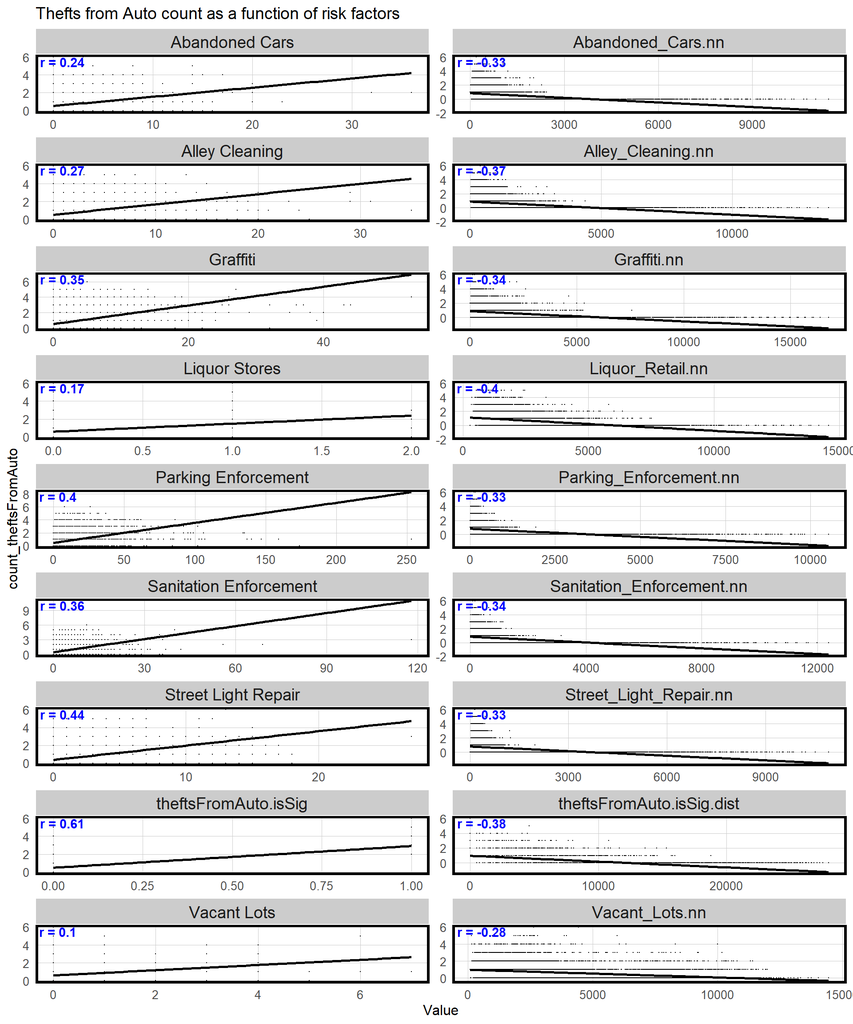

```r
correlation.long <-
  st_drop_geometry(final_net) %>%
    dplyr::select(-uniqueID, -cvID, -NAME, -Area) %>%
    gather(Variable, Value, -count_theftsFromAuto)

correlation.cor <-
  correlation.long %>%
    group_by(Variable) %>%
    summarize(correlation = cor(Value, count_theftsFromAuto, use = "complete.obs"))

ggplot(correlation.long, aes(Value, count_theftsFromAuto)) +
  geom_point(size = 0.1) +
  geom_text(data = correlation.cor, aes(label = paste("r =", round(correlation, 2))),
            x=-Inf, y=Inf, vjust = 1.25, hjust = -0.1, colour="blue", fontface ="bold") +
  geom_smooth(method = "lm", se = FALSE, colour = "black") +
  facet_wrap(~Variable, ncol = 2, scales = "free") +
  labs(title = "Thefts from Auto count as a function of risk factors") +
  plotTheme()
```

# Regressions

## Histogram of the Outcome Variable

In this histogram below showing distribution of thefts from auto incidents, a majority of grid cells have 0 or 1 incident of this crime type, indicating that theft from auto is a relatively rare crime event across the cells. Given this skewed distribution towards low frequency, an ordinary least squares (OLS) regression is not the best approach. Instead, a Poisson regression - a regression used in modeling an outcome variable consisting of count data - is more useful here.

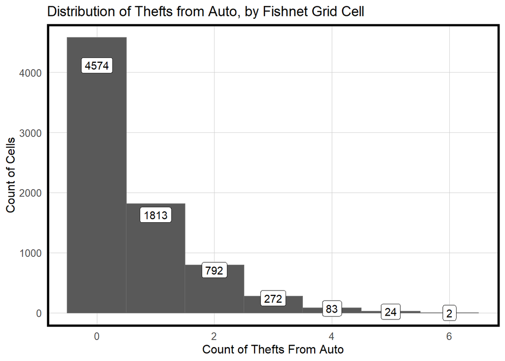

```r
# histogram of outcome variable
ggplot(final_net, aes(count_theftsFromAuto)) +
  geom_histogram(binwidth=1, color="grey40") +
  stat_bin(binwidth=1, geom="label", color="black", bins=6, aes(label=..count..), position=position_stack(vjust=0.9)) +
  labs(title="Distribution of Thefts from Auto, by Fishnet Grid Cell",
       y="Count of Cells", x = "Count of Thefts From Auto") + plotTheme()
```

## Cross-validated Poisson Regressions

To develop a model that will be generalizable, it needs to learn the risk of the theft by auto incidents across spatial scales - both city-wide and locally. This leads to the use of the “leave-one-group-out” spatial cross-validation approach (LOGO-CV). In this case, “groups” are the neighborhoods of DC. By training the model on all neighborhood except for one at a time - predicting the hold out and recording the goodness of fit for each - LOGO-CV rotates through and trains the model across various spatial scales.

Below, four regressions are run using the CrossValidate function, which incorporates the count_theftsFromAuto variable. Two regressions are random k-fold cross-validation, and the other two use the LOGO-CV spatial cross-validation approach.

- reg.cv: random k-fold cross validation using risk factors only
- reg.ss.cv: random k-fold cross validation using the risk factors and spatial process features
- reg.spatialCV: LOGO-CV spatial cross-validation on neighborhood, using the risk factors only
- reg.ss.spatialCV: LOGO-CV spatial cross-validation on neighborhood, using risk factors and spatial process features

```r
# just risk factors (reg.vars)
reg.vars <- c("Abandoned_Cars.nn", "Alley_Cleaning.nn", "Graffiti.nn", "Liquor_Retail.nn", "Parking_Enforcement.nn", "Sanitation_Enforcement.nn", "Street_Light_Repair.nn", "Vacant_Lots.nn")

## risk factors plus local morans I spatial process features (reg.ss.vars)
reg.ss.vars <- c("Abandoned_Cars.nn", "Alley_Cleaning.nn", "Graffiti.nn", "Liquor_Retail.nn", "Parking_Enforcement.nn", "Sanitation_Enforcement.nn", "Street_Light_Repair.nn", "Vacant_Lots.nn", "theftsFromAuto.isSig", "theftsFromAuto.isSig.dist")
```

```r
## run regressions
reg.cv <- crossValidate(
  dataset = final_net,
  id = "cvID",
  dependentVariable = "count_theftsFromAuto",
  indVariables = reg.vars) %>%
    dplyr::select(cvID = cvID, count_theftsFromAuto, Prediction, geometry)

reg.ss.cv <- crossValidate(
  dataset = final_net,
  id = "cvID",
  dependentVariable = "count_theftsFromAuto",
  indVariables = reg.ss.vars) %>%
    dplyr::select(cvID = cvID, count_theftsFromAuto, Prediction, geometry)

reg.spatialCV <- crossValidate(
  dataset = final_net,
  id = "NAME",
  dependentVariable = "count_theftsFromAuto",
  indVariables = reg.vars) %>%
    dplyr::select(cvID = NAME, count_theftsFromAuto, Prediction, geometry)

reg.ss.spatialCV <- crossValidate(
  dataset = final_net,
  id = "NAME",
  dependentVariable = "count_theftsFromAuto",
  indVariables = reg.ss.vars) %>%
    dplyr::select(cvID = NAME, count_theftsFromAuto, Prediction, geometry)
```

# Accuracy and Generalizability

## Model Errors

```r
# reg summary
reg.summary <-
  rbind(
    mutate(reg.cv,           Error = Prediction - count_theftsFromAuto,
                             Regression = "Random k-fold CV: Just Risk Factors"),

    mutate(reg.ss.cv,        Error = Prediction - count_theftsFromAuto,
                             Regression = "Random k-fold CV: Spatial Process"),

    mutate(reg.spatialCV,    Error = Prediction - count_theftsFromAuto,
                             Regression = "Spatial LOGO-CV: Just Risk Factors"),

    mutate(reg.ss.spatialCV, Error = Prediction - count_theftsFromAuto,
                             Regression = "Spatial LOGO-CV: Spatial Process")) %>%
    st_sf()
```

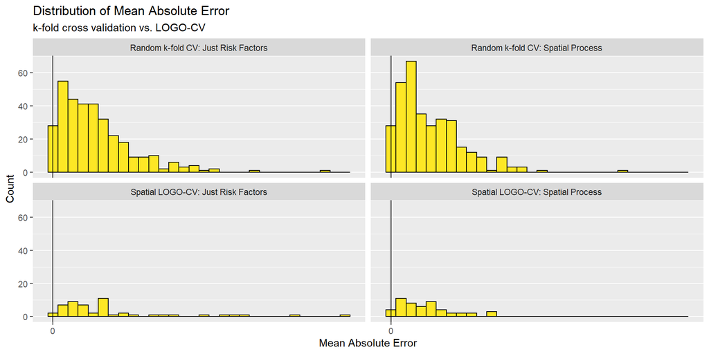

```r
# calculate errors
error_by_reg_and_fold <-
  reg.summary %>%
    group_by(Regression, cvID) %>%
    summarize(Mean_Error = mean(Prediction - count_theftsFromAuto, na.rm = T),
              MAE = mean(abs(Mean_Error), na.rm = T),
              SD_MAE = mean(abs(Mean_Error), na.rm = T)) %>%
  ungroup()

## plot histogram of OOF (out of fold) errors
error_by_reg_and_fold %>%
  ggplot(aes(MAE)) +
    geom_histogram(bins = 30, colour="black", fill = "#FDE725FF") +
    facet_wrap(~Regression) +
    geom_vline(xintercept = 0) + scale_x_continuous(breaks = seq(0, 8, by = 1)) +
    labs(title="Distribution of Mean Absolute Error", subtitle = "k-fold cross validation vs. LOGO-CV",
         x="Mean Absolute Error", y="Count")
```

To visualize the errors of these regressions, the maps below show the spatial distributions of errors. Areas with higher errors indicate that there are local spatial processes that are unaccounted for in the model. In the Spatial LOGO-CV: Just Risk Factors map especially, it is evident that the largest errors are in the hotspot areas. Given that these areas experience more of the incidents than others, is it expected that these areas would have more errors. Since the results of the k-fold cross validations are difficult to decipher, the histogram above provides a better view of the distribution of errors.

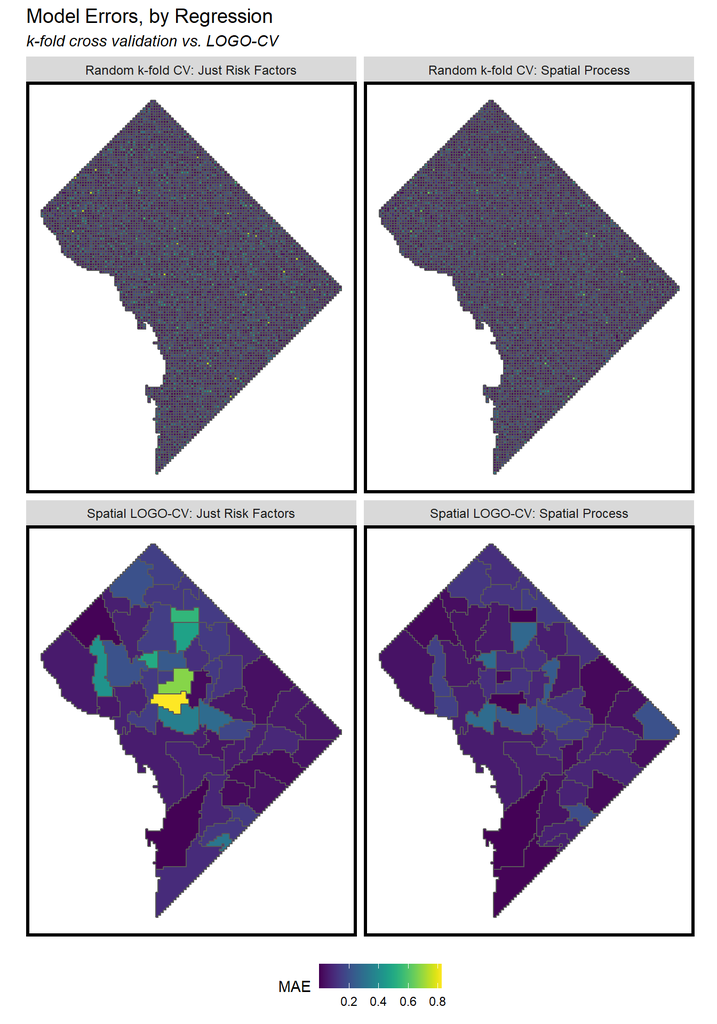

```r
error_by_reg_and_fold %>%
  #filter(str_detect(Regression, "k-fold")) %>%
  ggplot() +
    geom_sf(aes(fill = MAE)) +
    facet_wrap(~Regression) +
    scale_fill_viridis() +
    labs(title = "Model Errors, by Regression",
         subtitle = "k-fold cross validation vs. LOGO-CV") +
    mapTheme() + theme(legend.position="bottom") + theme(strip.text.x = element_text(size=9))
```

This table shows the MAE and standard deviation (SD) MAE for each of the four regressions. These results show that the inclusion of spatial process features improves the model (as shown by the smaller mean MAE and standard deviation MAE results). This confirms that accounting for spatial contexts in the model is useful.

```r
st_drop_geometry(error_by_reg_and_fold) %>%
  group_by(Regression) %>%
    summarize(Mean_MAE = round(mean(MAE), 2),
              SD_MAE = round(sd(MAE), 2)) %>%
  kable(caption = "Mean Absolute Error, By Regression") %>%
    kable_styling("striped", full_width = F) %>%
    row_spec(2, color = "black", background = "#FDE725FF") %>%
    row_spec(4, color = "black", background = "#FDE725FF")
```

Mean Absolute Error, By Regression

| Regression | Mean_MAE | SD_MAE |
| --- | --- | --- |
| Random k-fold CV: Just Risk Factors | 0.12 | 0.10 |
| Random k-fold CV: Spatial Process | 0.11 | 0.09 |
| Spatial LOGO-CV: Just Risk Factors | 0.16 | 0.18 |
| Spatial LOGO-CV: Spatial Process | 0.10 | 0.08 |

## Model Predictions

The maps below show the predictions for the four regressions. With a smoother crime risk surface, these mapped predictions represent latent crime risk. This means that they show that areas are at risk, even if no incident was observed there.

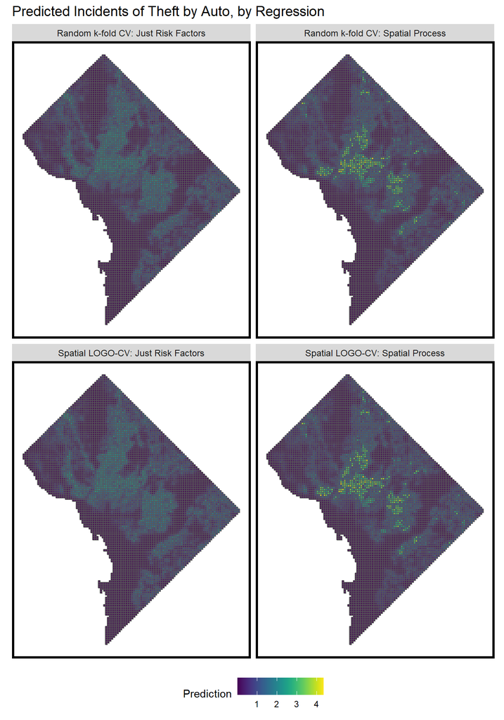

```r
#mapping predictions

  reg.summary %>%
  ggplot()+
    geom_sf(aes(fill = Prediction)) +
    facet_wrap(~Regression) +
    scale_fill_viridis() +
    labs(title = "Predicted Incidents of Theft by Auto, by Regression") +
    mapTheme() + theme(legend.position="bottom") + theme(strip.text.x = element_text(size=9))
```

Looking at just the Spatial Process features to further investigate their role in accounting for spaital variation, I calculate Moran’s *I* on errors for the LOGO-CV regressions.

```r
#neighborhood weights
neighborhood.weights <-
  filter(error_by_reg_and_fold, Regression == "Spatial LOGO-CV: Spatial Process") %>%
    group_by(cvID) %>%
      poly2nb(as_Spatial(.), queen=TRUE) %>%
      nb2listw(., style="W", zero.policy=TRUE)

filter(error_by_reg_and_fold, str_detect(Regression, "LOGO"))  %>%
    st_drop_geometry() %>%
    group_by(Regression) %>%
    summarize(Morans_I = moran.mc(abs(Mean_Error), neighborhood.weights,
                                 nsim = 999, zero.policy = TRUE,
                                 na.action=na.omit)[[1]],
              p_value = moran.mc(abs(Mean_Error), neighborhood.weights,
                                 nsim = 999, zero.policy = TRUE,
                                 na.action=na.omit)[[3]]) %>% kable() %>% kable_styling()
```

[output not shown]

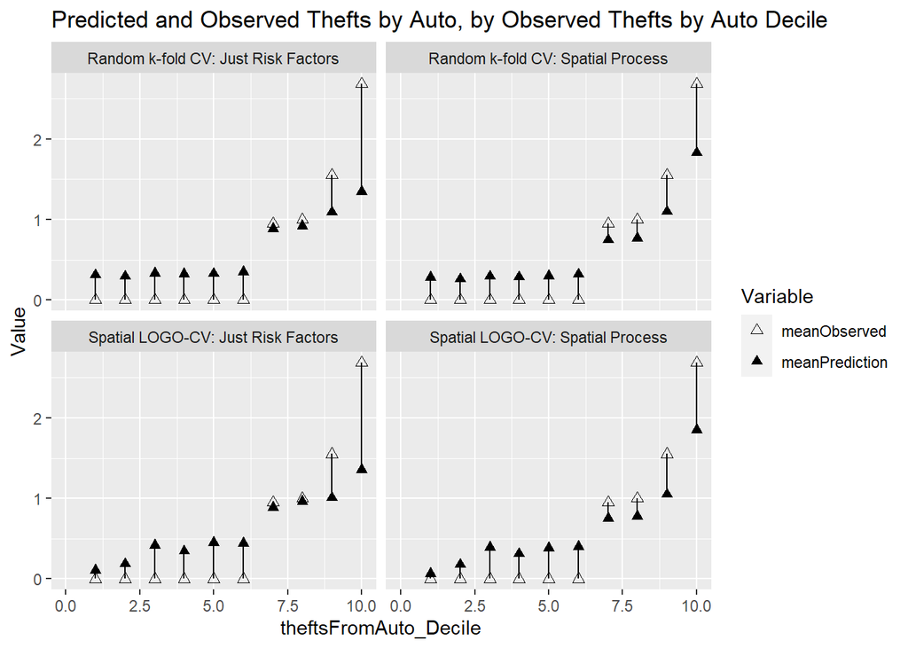

```r
st_drop_geometry(reg.summary) %>%
  group_by(Regression) %>%
    mutate(theftsFromAuto_Decile = ntile(count_theftsFromAuto, 10)) %>%
  group_by(Regression, theftsFromAuto_Decile) %>%
    summarize(meanObserved = mean(count_theftsFromAuto, na.rm=T),
              meanPrediction = mean(Prediction, na.rm=T)) %>%
    gather(Variable, Value, -Regression, -theftsFromAuto_Decile) %>%
    ggplot(aes(theftsFromAuto_Decile, Value, shape = Variable)) +
      geom_point(size = 2) + geom_path(aes(group = theftsFromAuto_Decile), colour = "black") +
      scale_shape_manual(values = c(2, 17)) +
      facet_wrap(~Regression) + xlim(0,10) +
      labs(title = "Predicted and Observed Thefts by Auto, by Observed Thefts by Auto Decile")
```

# Generalizability by Neighborhood Context

To test that the model generalizes across neighborhood contexts in DC, I bring in data from the U.S. Census Bureau’s American Community Survey estimates. The most recent year available through the API is 2018, so I pull in data for population and race, by Census tract.

```r
census_api_key("41e1c0d912341017fa6f36a5da061d3b23de335e", overwrite = TRUE)

tracts2018 <-
  get_acs(geography = "tract", variables = c("B01001_001E", "B01001A_001E"),
          year = 2018, state=11,county=001, geometry=T) %>%
  st_transform('ESRI:102685')  %>%
  dplyr::select(variable, estimate, GEOID) %>%
  spread(variable, estimate) %>%
  rename(TotalPop = B01001_001,
         NumberWhites = B01001A_001) %>%
  mutate(percentWhite = NumberWhites / TotalPop,
         raceContext = ifelse(percentWhite > .5, "Majority_White", "Majority_Non_White")) %>%
  .[neighborhoods,]
```

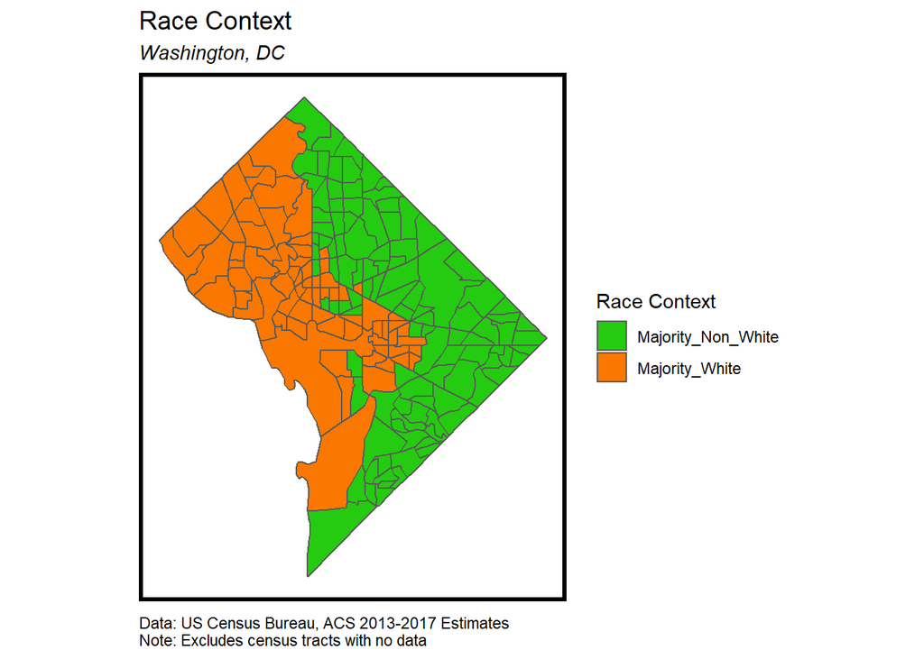

```r
ggplot()+
      geom_sf(data = na.omit(tracts2018), aes(fill = raceContext)) +
    scale_fill_manual(values = c("#25CB10", "#FA7800"), name="Race Context") +
    labs(title = "Race Context", subtitle = "Washington, DC", caption="Data: US Census Bureau, ACS 2013-2017 Estimates \nNote: Excludes census tracts with no data")+
    mapTheme() + theme(legend.position="right")
```

Overall, the model errors are lower when accounting for neighborhood racial context, and when bringing in the spatial process features, these errors are even lower. Especially in the majority-non-white context, slightly under-predicting is the best option in my opinion - if this model were to be used, it would not lead to unnecessary over-allocation of resources to areas with a large percentage of minorities.

```r
 reg.summary %>%
  filter(str_detect(Regression, "LOGO")) %>%
    st_centroid() %>%
    st_join(tracts2018) %>%
    na.omit() %>%
      st_drop_geometry() %>%
      group_by(Regression, raceContext) %>%
      summarize(mean.Error = mean(Error, na.rm = T)) %>%
      spread(raceContext, mean.Error) %>%
      kable(caption = "Mean Error by neighborhood racial context") %>%
        kable_styling("striped", full_width = F)
```

Mean Error by neighborhood racial context

| Regression | Majority_Non_White | Majority_White |
| --- | --- | --- |
| Spatial LOGO-CV: Just Risk Factors | 0.0287460 | -0.0364293 |
| Spatial LOGO-CV: Spatial Process | -0.0074779 | 0.0041484 |

## Do Risk Predictions Outperform Kernel Density Hotspot Mapping?

This section looks at the risk predictions and compares their performance to more traditional kernel density hotspot mapping. Kernel density works by calculating the density of features based on the sum of all nearby “kernels” in a given area. The series of three maps below show kernel density for theft from auto incidents in 2018 at three different scales. It is important to keep in mind that this type of mapping can easily change the visual story of where “hotspots” are and what the magnitudes may be, based on what scale is chosen. In this way, predictions are based on spatial autocorrelation.

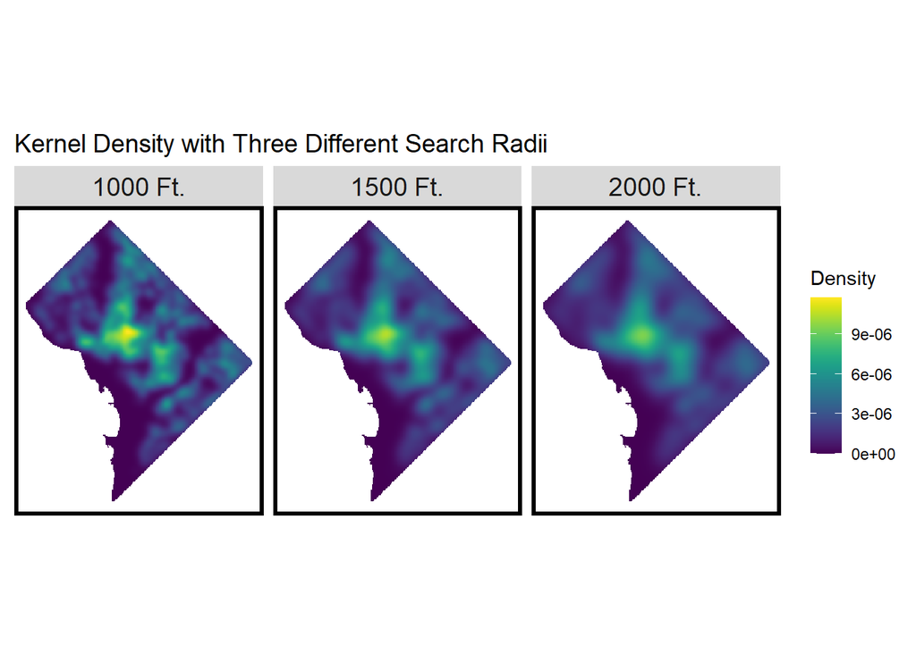

```r
spatstat.options(npixel=c(256,256))

tfa_ppp <- as.ppp(st_coordinates(theftsFromAuto), W = st_bbox(final_net))
tfa_KD.1000 <- spatstat::density.ppp(tfa_ppp, 1000)
tfa_KD.1500 <- spatstat::density.ppp(tfa_ppp, 1500)
tfa_KD.2000 <- spatstat::density.ppp(tfa_ppp, 2000)
tfa_KD.df <- rbind(
  mutate(data.frame(rasterToPoints(mask(raster(tfa_KD.1000), as(neighborhoods, 'Spatial')))), Legend = "1000 Ft."),
  mutate(data.frame(rasterToPoints(mask(raster(tfa_KD.1500), as(neighborhoods, 'Spatial')))), Legend = "1500 Ft."),
  mutate(data.frame(rasterToPoints(mask(raster(tfa_KD.2000), as(neighborhoods, 'Spatial')))), Legend = "2000 Ft."))

tfa_KD.df$Legend <- factor(tfa_KD.df$Legend, levels = c("1000 Ft.", "1500 Ft.", "2000 Ft."))

ggplot(data=tfa_KD.df, aes(x=x, y=y)) +
  geom_raster(aes(fill=layer)) +
  facet_wrap(~Legend) +
  coord_sf(crs=st_crs(final_net)) +
  scale_fill_viridis(name="Density") +
  labs(title = "Kernel Density with Three Different Search Radii") +
  mapTheme()
```

This map illustrates a sample of 1,500 observed theft from auto incidents from 2018 mapped on top of the 1000-ft kernel density.

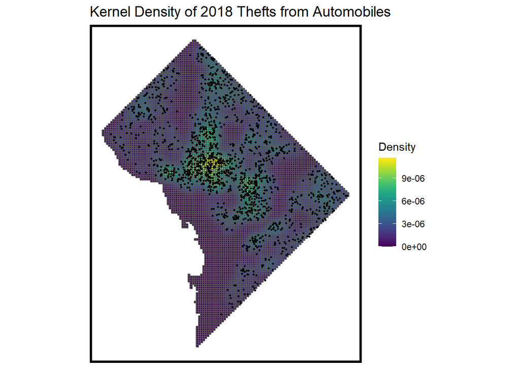

```r
tfa_KD_ppp <- as.ppp(st_coordinates(theftsFromAuto), W = st_bbox(final_net))
tfa_KD <- spatstat::density.ppp(tfa_KD_ppp, 1000)


kden <- as.data.frame(tfa_KD)  %>%
  st_as_sf(coords = c("x", "y"), crs = st_crs(final_net)) %>%
  aggregate(., final_net, mean)

  ggplot(kden) +
     geom_sf(aes(fill=value)) +
     geom_sf(data = sample_n(theftsFromAuto, 1500), size = .5) +
     scale_fill_viridis(name = "Density") +
     labs(title = "Kernel Density of 2018 Thefts from Automobiles") +
     mapTheme()
```

## Comparison of Kernel Density and Risk Predictions

```r
#new goodness of fit indicate to see whether 2018 kernel density or risk prediction captures more of the 2019 burglaries

theftsFromAuto2019 <-
  st_read("https://opendata.arcgis.com/datasets/f08294e5286141c293e9202fcd3e8b57_1.geojson") %>%
    filter(OFFENSE == "THEFT F/AUTO") %>%
    mutate(X = as.numeric(LONGITUDE),Y = as.numeric(LATITUDE)) %>%
    filter(!is.na(X)) %>%
    filter(!is.na(Y)) %>%
    st_as_sf(coords = c("X", "Y"), crs = 4326, agr = "constant") %>%
    st_transform('ESRI:102685') %>%
    distinct() %>%
    .[fishnet,]
tfa_KDE_sf <- as.data.frame(tfa_KD) %>%
  st_as_sf(coords = c("x", "y"), crs = st_crs(final_net)) %>%
  aggregate(., final_net, mean) %>%
  mutate(label = "Kernel Density",
         Risk_Category = ntile(value, 100),
         Risk_Category = case_when(
           Risk_Category >= 90 ~ "90% to 100%",
           Risk_Category >= 70 & Risk_Category <= 89 ~ "70% to 89%",
           Risk_Category >= 50 & Risk_Category <= 69 ~ "50% to 69%",
           Risk_Category >= 30 & Risk_Category <= 49 ~ "30% to 49%",
           Risk_Category >= 1 & Risk_Category <= 29 ~ "1% to 29%")) %>%
  cbind(
    aggregate(
      dplyr::select(theftsFromAuto2019) %>% mutate(tfaCount = 1), ., sum) %>%
    mutate(tfaCount = replace_na(tfaCount, 0))) %>%
  dplyr::select(label, Risk_Category, tfaCount)

tfa_risk_sf <-
  reg.ss.spatialCV %>%
  mutate(label = "Risk Predictions",
         Risk_Category = ntile(Prediction, 100),
         Risk_Category = case_when(
         Risk_Category >= 90 ~ "90% to 100%",
         Risk_Category >= 70 & Risk_Category <= 89 ~ "70% to 89%",
         Risk_Category >= 50 & Risk_Category <= 69 ~ "50% to 69%",
         Risk_Category >= 30 & Risk_Category <= 49 ~ "30% to 49%",
         Risk_Category >= 1 & Risk_Category <= 29 ~ "1% to 29%")) %>%
  cbind(
    aggregate(
      dplyr::select(theftsFromAuto2019) %>% mutate(tfaCount = 1), ., sum) %>%
      mutate(tfaCount = replace_na(tfaCount, 0))) %>%
  dplyr::select(label, Risk_Category, tfaCount)
```

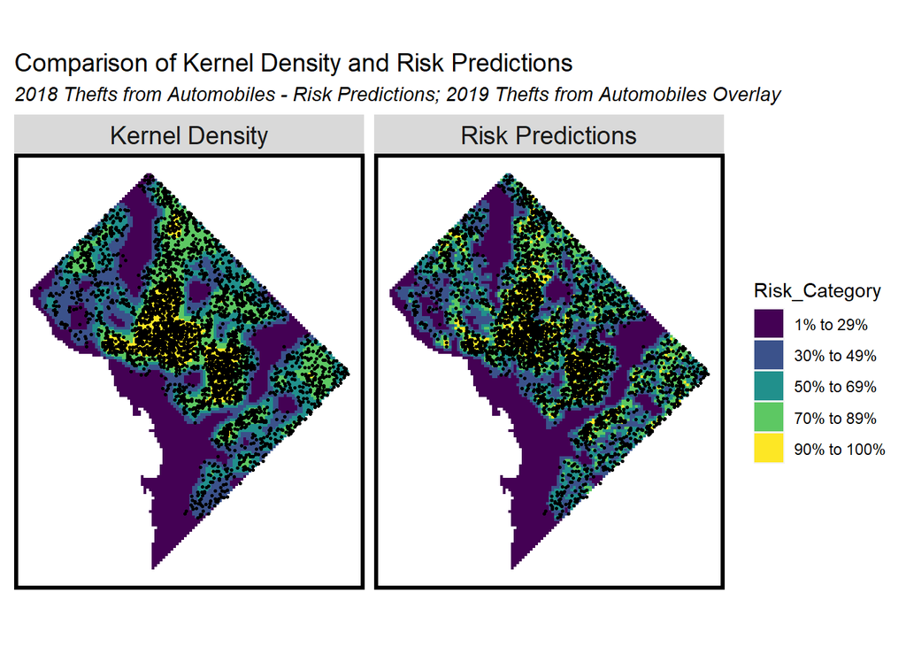

```r
rbind(tfa_KDE_sf, tfa_risk_sf) %>%
  na.omit() %>%
  gather(Variable, Value, -label, -Risk_Category, -geometry) %>%
  ggplot() +
    geom_sf(aes(fill = Risk_Category), colour = NA) +
    geom_sf(data = sample_n(theftsFromAuto2019, 3000), size = .5, colour = "black") +
    facet_wrap(~label, ) +
    scale_fill_viridis(discrete = TRUE) +
    labs(title="Comparison of Kernel Density and Risk Predictions",
         subtitle="2018 Thefts from Automobiles - Risk Predictions; 2019 Thefts from Automobiles Overlay") +
    mapTheme()
```

This final graphic helps to better understand the performance of the risk prediction modeling versus kernel density. In the top three risk categories, the risk prediction model performs better than kernel density. This indicates that the model is well-fit, and its better performance compared to a more traditional crime prediction method used commonly in the public sector shows that the approach may be valuable in police resource allocation decision-making. However, as discussed in the conclusion below, predictive models for addressing crime may not be the most effective approach for a community at large.

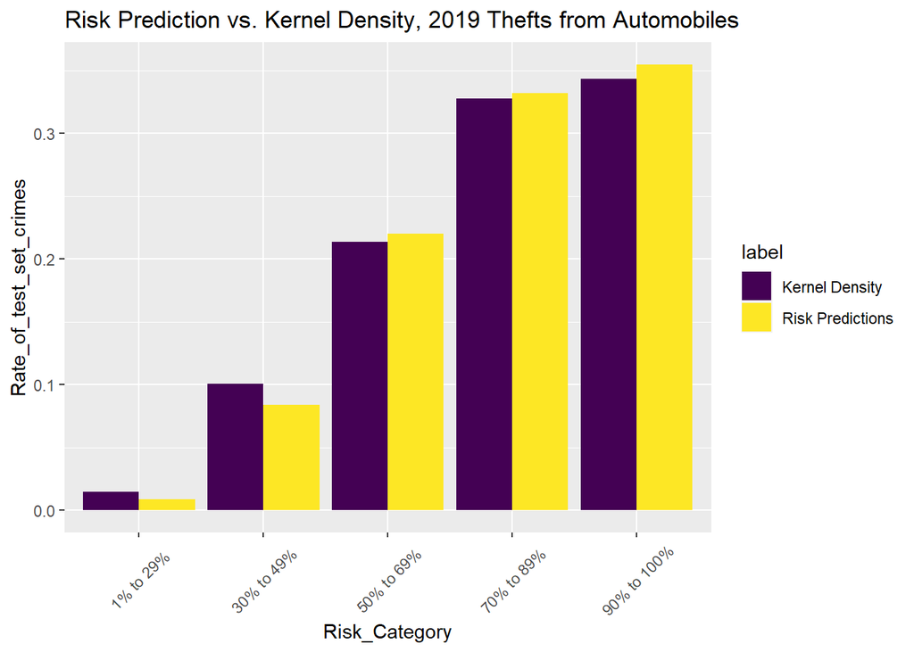

```r
rbind(tfa_KDE_sf, tfa_risk_sf) %>%
  st_set_geometry(NULL) %>% na.omit() %>%
  gather(Variable, Value, -label, -Risk_Category) %>%
  group_by(label, Risk_Category) %>%
  summarize(count_theftsFromAuto = sum(Value)) %>%
  ungroup() %>%
  group_by(label) %>%
  mutate(Rate_of_test_set_crimes = count_theftsFromAuto / sum(count_theftsFromAuto)) %>%
    ggplot(aes(Risk_Category,Rate_of_test_set_crimes)) +
      geom_bar(aes(fill=label), position="dodge", stat="identity") +
      scale_fill_viridis(discrete = TRUE) +
      labs(title = "Risk Prediction vs. Kernel Density, 2019 Thefts from Automobiles") +
      theme(axis.text.x = element_text(angle = 45, vjust = 0.5))
```

# Conclusion

Despite the accuracy and generalizability of the model (especially in neighborhood contexts, due to the slight underprediction in majority non-White areas) I would not recommend using a geospatial risk model in allocating police resources. I think there are other deep-rooted issues in the way that law enforcement practices exist, and I believe that a fundamental restructuring of law enforcement is needed to reevaluate community needs and how they can be addressed without further exacerbating racial and economic divides.

Through this process, I have learned that geospatial risk modeling can be a useful alternative to hotspot mapping, and iteratively developing a model to incorporate various risk features is a valuable process. However, I think that this type of modeling would be better suited to address other public policy challenges in sectors that do not have similarly deep-rooted issues of systemic bias. In the era of COVID-19, I am interested in leveraging this process to build a model identifying areas at higher risk of exposure, using features like density of multi-family housing units and homeless shelters, to help public agencies determine where to target public health efforts.